# Comparison of blocking data for JRA, MERRA, CFSR, ERA

2018-12-13

This is the results summary for JJA SP, comparing four reanalysis datasets (ERA-Interim, MERRA-2, CFSR, JRA.

### Initial summary information

|  | JRA | MERRA | CFSR | ERA |
| --- | --- | --- | --- | --- |
| Number of years in dataset | 25 | 25 | 25 | 25 |
| Number of unique blobs | 244 | 228 | 208 | 243 |
| Number of merged blobs | 65 | 63 | 61 | 64 |
| Maximum blocking frequency | 0.1002 | 0.0993 | 0.0888 | 0.1070 |
| Interquartile range of blob centroid latitude | -58.12 -33.12 | -57.50 -33.25 | -58.00 -33.50 | -58.00 -33.00 |
| Number of blocked days | 1772 | 1660 | 1573 | 1785 |
| Average number of blocked days (divided by number of years) | 70.88 | 66.40 | 62.92 | 71.40 |
| Interquartile range of duration (days) | 6.75 11.25 | 6.75 11.06 | 6.75 11.25 | 6.75 11.62 |
| Interquartile range of speed (km/hr) | 4.98 14.23 | 5.38 14.73 | 5.49 15.65 | 4.61 14.99 |
| Interquartile range of blob size (10^6 km^2) | 25.09 56.04 | 25.62 55.85 | 26.20 57.16 | 25.09 55.75 |

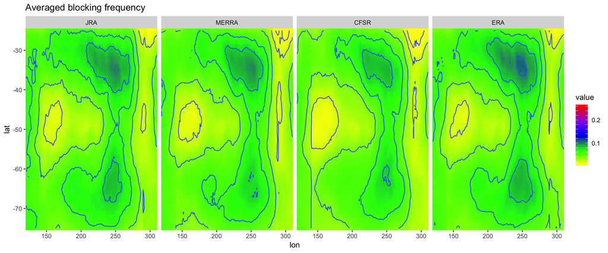

### Pearson Pattern Correlation

This chart shows the Pearson pattern correlation values between the average blocking patterns of the various models. The scale is from 0 to 1, but it should be noted that this metric will have a high correlation value even if the magnitudes of corresponding grid points differ.

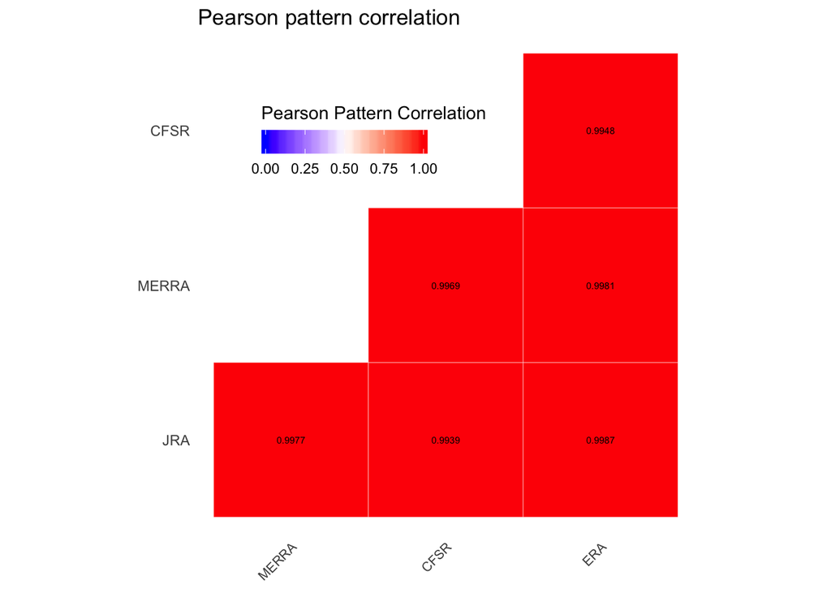

### Root Mean Square Error

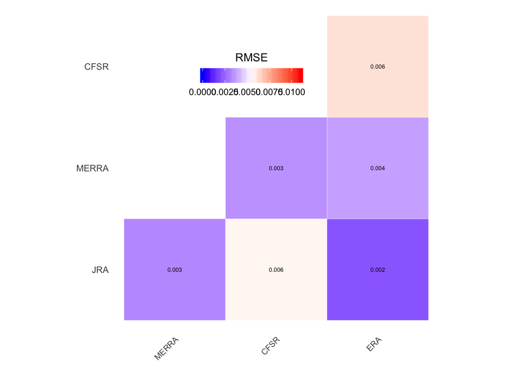

### Block duration

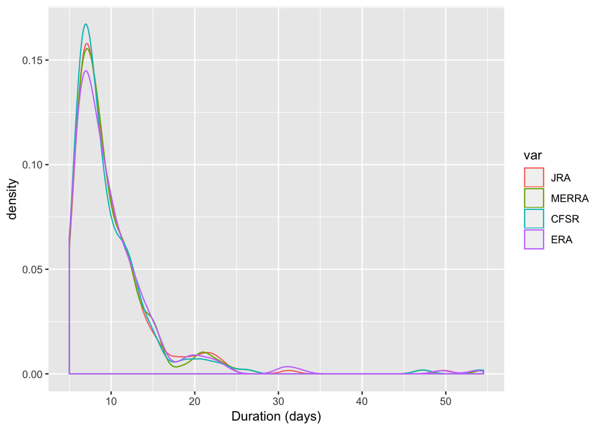

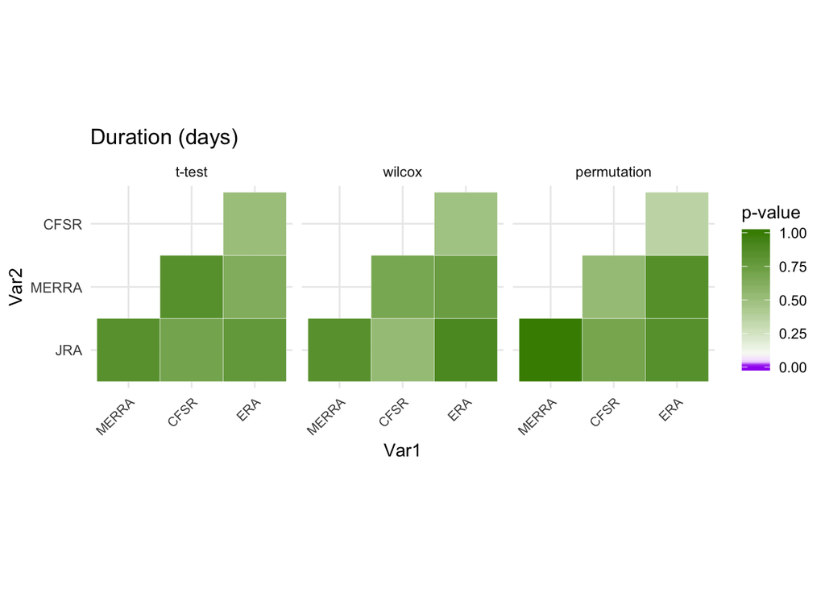

### Block zonal speed

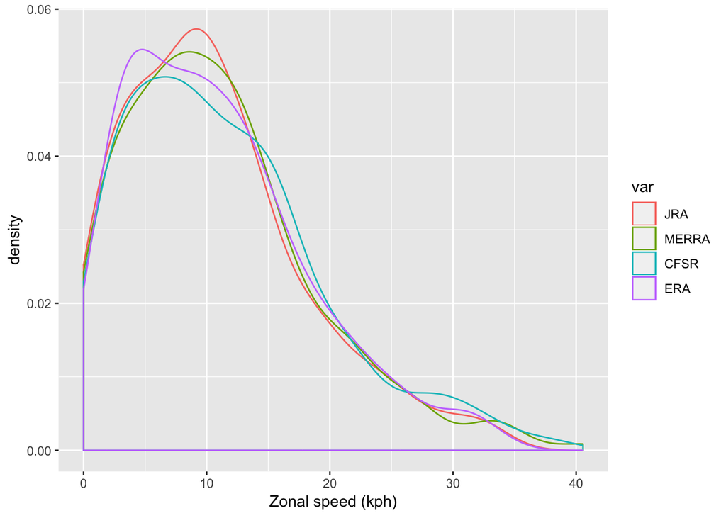

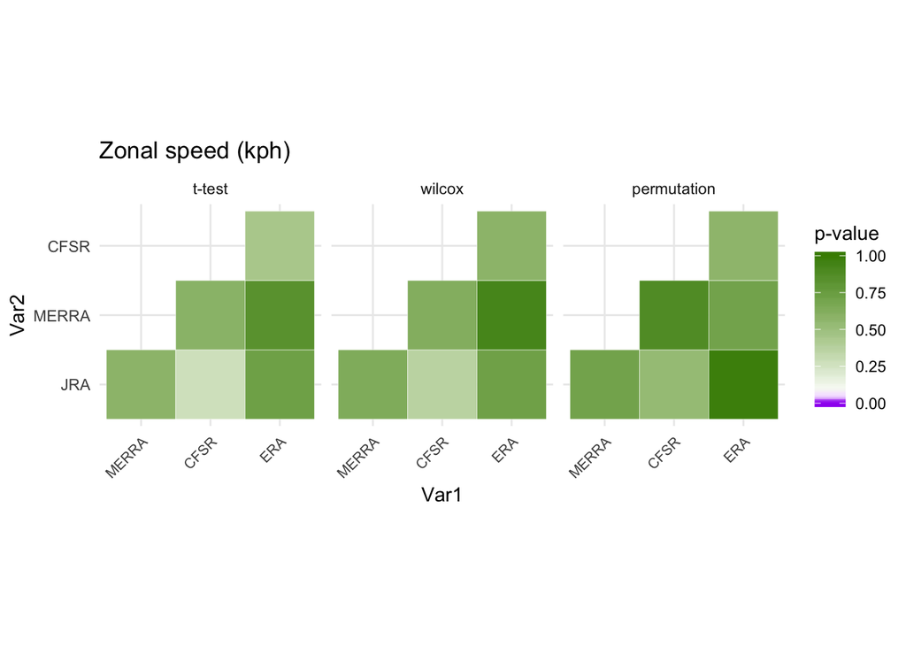

### Block size

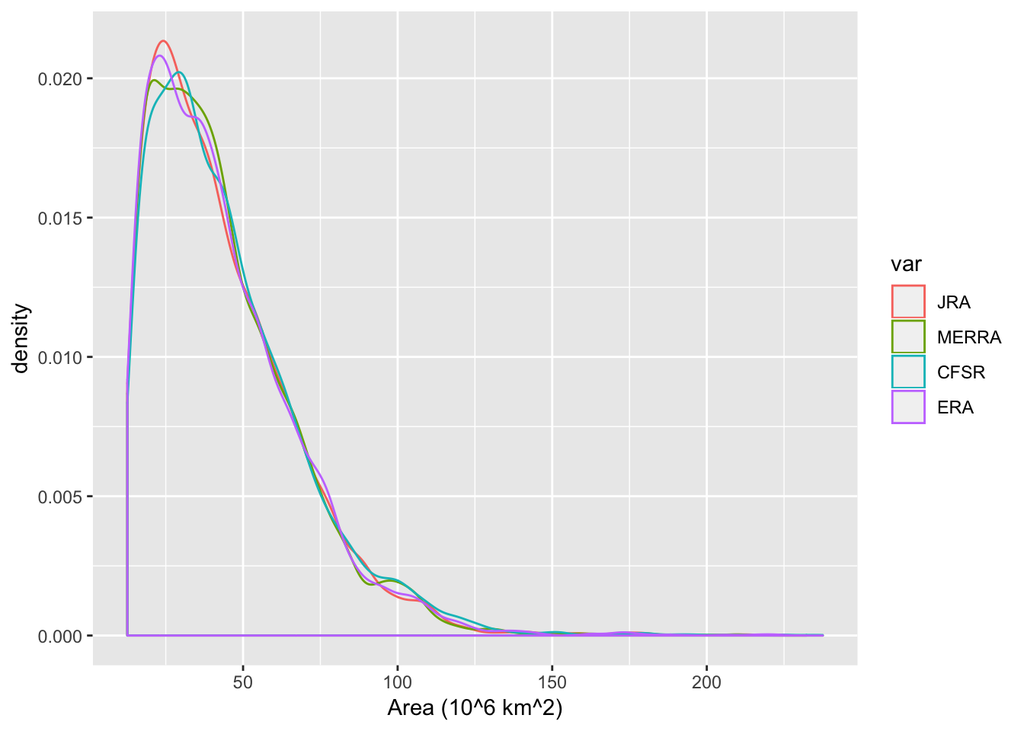

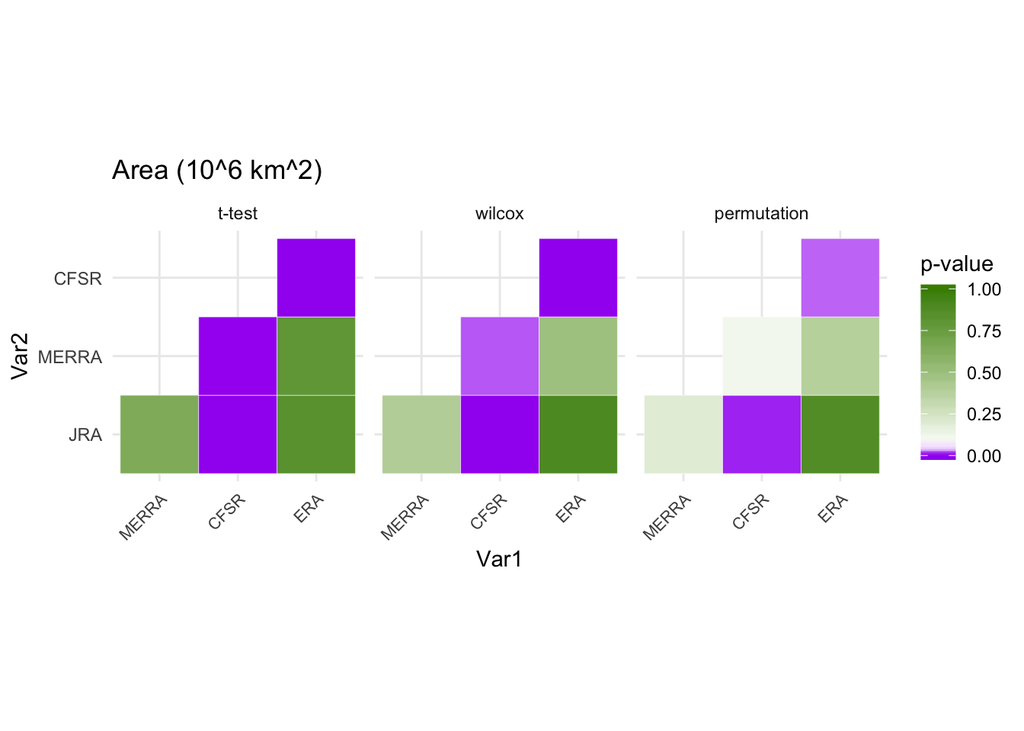

### Probability of Co-occurrence

This chart shows the probability of co-occurrence, where the upper triangle is the probability of the y-axis variable given the x-axis variable ($P(y|x)$) and the lower triangle is the probability of the x-axis variable given the y-axis variable ($P(x|y)$). The scale is from 0 to 1.

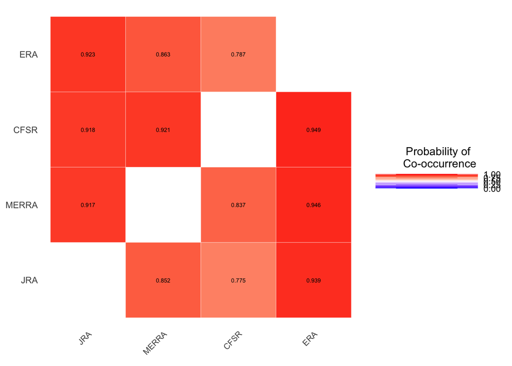

### Spatial Similarity

Spatial similarity is the amount of commonly detected blocked area as defined by blocks from two datasets that are present in the same time step and have at least some overlap. Perfect agreement would have a value of 1. These charts show the 50th percentile similarity values (top) as well as the distribution of similarity values (bottom). The scale is from 0 to 1.

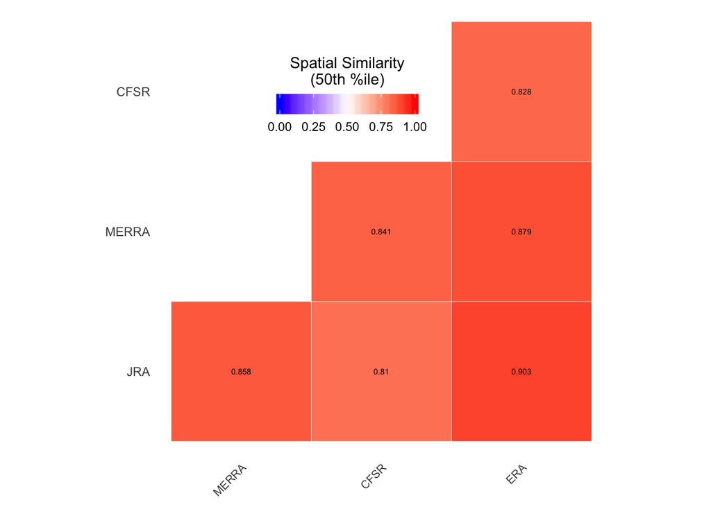

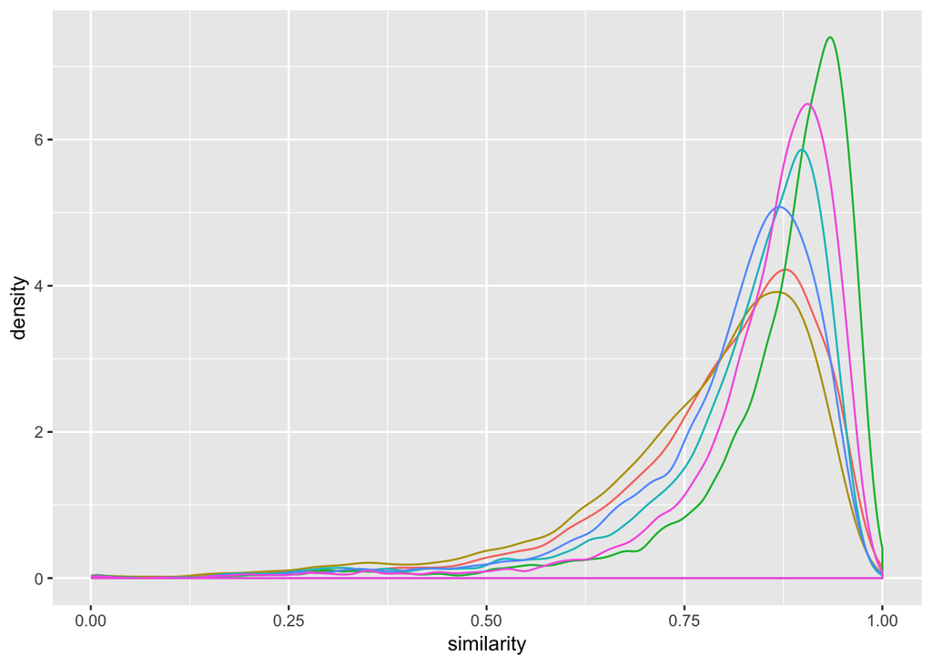